# Chapter 3 - Logistic regression

Let’s download the data we’re using for this exercise and explore the structure.

```r
student_alc <- read.table("pormath.txt")

dim(student_alc)
```

```
## [1] 370  51
```

```r
str(student_alc)
```

```
## 'data.frame':    370 obs. of  51 variables:
##  $ school    : Factor w/ 2 levels "GP","MS": 1 1 1 1 1 1 1 1 1 1 ...
##  $ sex       : Factor w/ 2 levels "F","M": 1 1 1 1 1 1 1 1 1 1 ...
##  $ age       : int  15 15 15 15 15 15 15 15 15 15 ...
##  $ address   : Factor w/ 2 levels "R","U": 1 1 1 1 1 1 1 1 1 2 ...
##  $ famsize   : Factor w/ 2 levels "GT3","LE3": 1 1 1 1 1 1 1 2 2 1 ...
##  $ Pstatus   : Factor w/ 2 levels "A","T": 2 2 2 2 2 2 2 2 2 1 ...
##  $ Medu      : int  1 1 2 2 3 3 3 2 3 3 ...
##  $ Fedu      : int  1 1 2 4 3 4 4 2 1 3 ...
##  $ Mjob      : Factor w/ 5 levels "at_home","health",..: 1 3 1 4 4 4 4 2 3 3 ...
##  $ Fjob      : Factor w/ 5 levels "at_home","health",..: 3 3 3 2 4 2 5 4 3 2 ...
##  $ reason    : Factor w/ 4 levels "course","home",..: 2 4 4 1 4 1 1 4 4 4 ...
##  $ guardian  : Factor w/ 3 levels "father","mother",..: 2 2 2 2 3 2 1 2 1 1 ...
##  $ traveltime: int  2 1 1 1 2 1 2 2 2 1 ...
##  $ studytime : int  4 2 1 3 3 3 3 2 4 4 ...
```

[output cut: 37 more lines]

```r
head(student_alc)
```

```
##   school sex age address famsize Pstatus Medu Fedu     Mjob     Fjob     reason
## 1     GP   F  15       R     GT3       T    1    1  at_home    other       home
## 2     GP   F  15       R     GT3       T    1    1    other    other reputation
## 3     GP   F  15       R     GT3       T    2    2  at_home    other reputation
## 4     GP   F  15       R     GT3       T    2    4 services   health     course
## 5     GP   F  15       R     GT3       T    3    3 services services reputation
## 6     GP   F  15       R     GT3       T    3    4 services   health     course
##   guardian traveltime studytime schoolsup famsup activities nursery higher
## 1   mother          2         4       yes    yes        yes     yes    yes
## 2   mother          1         2       yes    yes         no      no    yes
## 3   mother          1         1       yes    yes        yes     yes    yes
## 4   mother          1         3       yes    yes        yes     yes    yes
## 5    other          2         3        no    yes        yes     yes    yes
## 6   mother          1         3       yes    yes        yes     yes    yes
##   internet romantic famrel freetime goout Dalc Walc health n id.p id.m failures
```

[output cut: 20 more lines]

The dataset includes student performance information in secondary education of two Portuguese schools. We have 370 students (rows or observations) and 51 attributes (columns or variables). These 51 variables include sex, grades (G1, G2, G3), age, school, and information about the student’s social and family factors. Two distinct school subjects were of interest: math and Portuguese language.

More details about the dataset can be found here: https://archive.ics.uci.edu/ml/datasets/Student+Performance

The data were wrangled with Reijo Sund’s code, so the dataset differs from the DataCamp set.

## Overview of the data

In this exercise we want to explore the relationship between alcohol consumption and academic performance. The dataset was modified to inlcude alc_use and high_use, the first including average alcohol consumption during the week. The latter was constructed so that high alcohol use was set to be over 2. We are only including G3 grades, since this column includes final grades.

Let’s look at high_use, absences, study time, failures and if there are differences between men and women. I hypothesise high consumption results in lower grades, more absences, less study time and more failures. I also hypothesise there are differences between the sexes.

First we’ll cross-tabulate. I excluded absences from cross-tabulation since the results were hard to interpret.

```r
library(tidyr); library(dplyr); library(ggplot2)
student_alc %>% group_by(failures, high_use) %>% summarise(count = n(), mean_grade = mean(G3))
```

```
## # A tibble: 8 x 4
## # Groups:   failures [4]
##   failures high_use count mean_grade
##      <int> <lgl>    <int>      <dbl>
## 1        0 FALSE      238      12.2
## 2        0 TRUE        87      11.5
## 3        1 FALSE       12       8.08
## 4        1 TRUE        12       9.25
## 5        2 FALSE        8       7
## 6        2 TRUE         9       8.33
## 7        3 FALSE        1      10
## 8        3 TRUE         3       7.33
```

```r
student_alc %>% group_by(studytime, high_use) %>% summarise(count = n(), mean_grade = mean(G3))
```

```
## # A tibble: 8 x 4
## # Groups:   studytime [4]
##   studytime high_use count mean_grade
##       <int> <lgl>    <int>      <dbl>
## 1         1 FALSE       56       11
## 2         1 TRUE        42       10.4
## 3         2 FALSE      128       11.8
## 4         2 TRUE        57       10.8
## 5         3 FALSE       52       12.4
## 6         3 TRUE         8       13
## 7         4 FALSE       23       12.3
## 8         4 TRUE         4       12.5
```

```r
student_alc %>% group_by(sex, high_use) %>% summarise(count = n(), mean_grade = mean(G3))
```

```
## # A tibble: 4 x 4
## # Groups:   sex [2]
##   sex   high_use count mean_grade
##   <fct> <lgl>    <int>      <dbl>
## 1 F     FALSE      154       11.4
## 2 F     TRUE        41       11.8
## 3 M     FALSE      105       12.3
## 4 M     TRUE        70       10.3
```

We see that 0 failures are associated with lower alcohol consumption and high alcohol consumption and 3 failures are associated with lower mean grade. Study time and no alcohol is associated with better grades, with the exception of study time 3 and high alcohol consumption. Also, men with high alcohol consumption seem to have lower grades.

Now for some plots, in which we separate by sex.

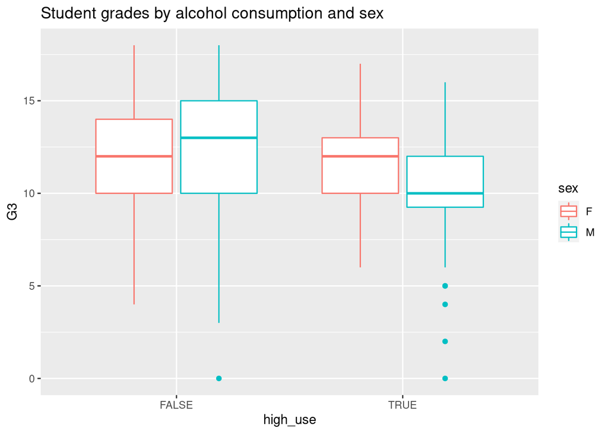

```r
ggplot(student_alc, aes(x = high_use, y = G3, col = sex))+ geom_boxplot() + ggtitle("Student grades by alcohol consumption and sex")
```

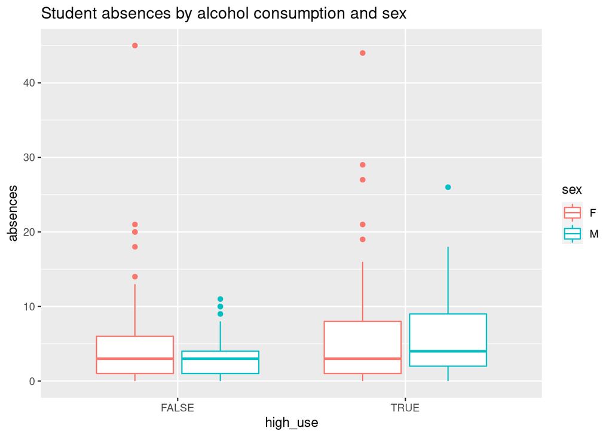

```r
ggplot(student_alc, aes(x = high_use, y = absences, col = sex))+ geom_boxplot() + ggtitle("Student absences by alcohol consumption and sex")
```

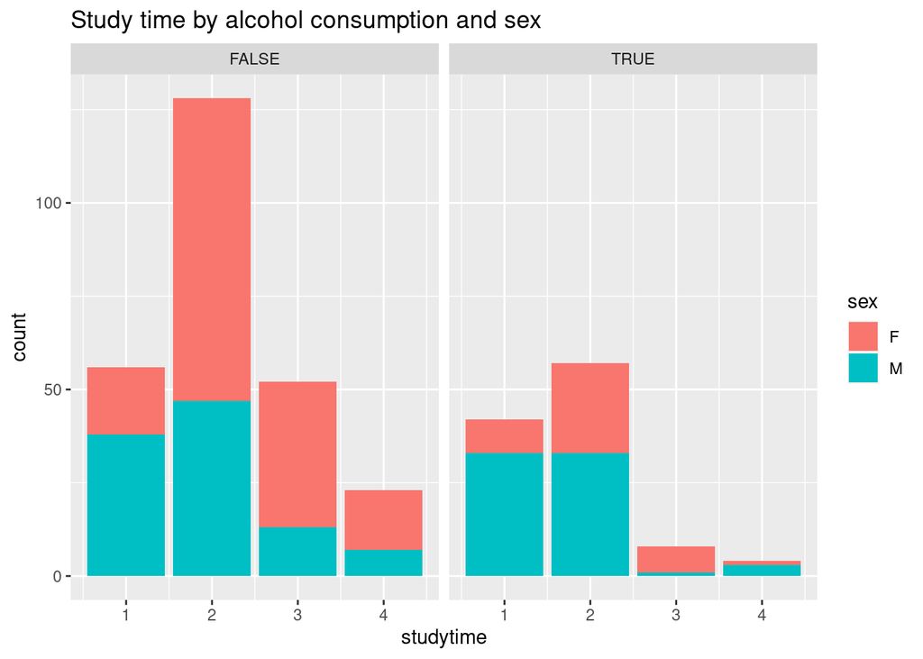

```r
ggplot(student_alc, aes(x=studytime, fill = sex)) + geom_bar() + ggtitle("Study time by alcohol consumption and sex") + facet_wrap(~high_use)
```

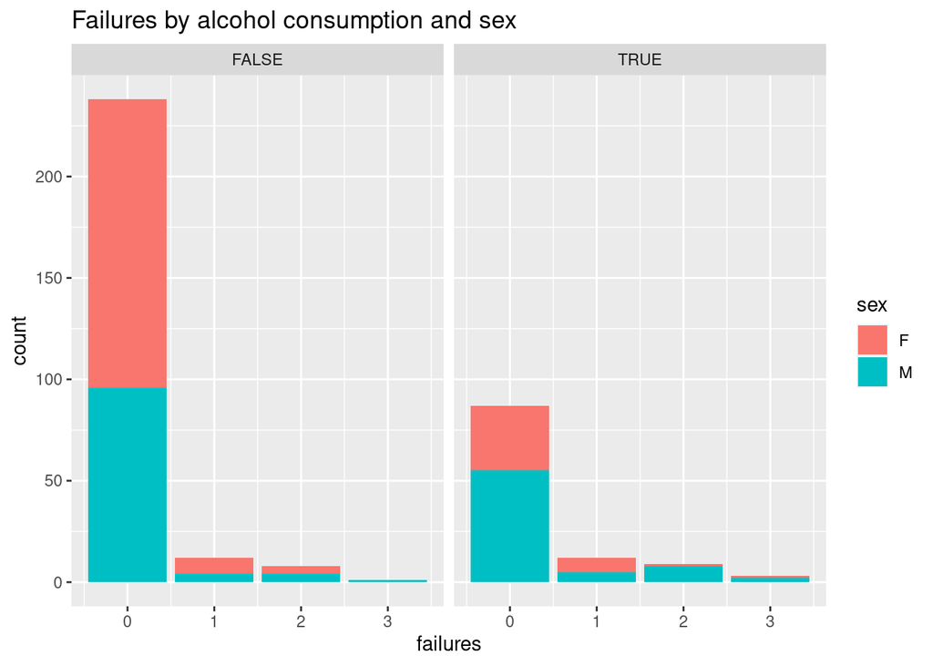

```r
ggplot(student_alc, aes(x=failures, fill = sex)) + geom_bar() + ggtitle("Failures by alcohol consumption and sex") + facet_wrap(~high_use)
```

From these plots we see that men’s grades are slightly lower when alcohol conpsumtion is high. Absences seem to be slightly more common when alcohol consumption is high. The students study less when consumption is high and they fail more often when alcohol consumption is high, especially men. However, it’s good to bear in mind that the total number of high consumers is lower compared to low consumers of alcohol. My initial hypothesis was not too far off, but I’m surprised how different the results are between men and women.

## Logistic regression

We’ll run a generalised linear model with binomial distribution. We’ll explore the relationship of high alcohol use to the previously discussed variables failures, absences, sex, study time and final year grades (G3).

```r
# Generalised linear model
model <- glm(high_use ~ failures + absences + sex + studytime + G3, data = student_alc, family = "binomial")

# Summary of the model
summary(model)
```

```
##
## Call:
## glm(formula = high_use ~ failures + absences + sex + studytime +
##     G3, family = "binomial", data = student_alc)
##
## Deviance Residuals:
##     Min       1Q   Median       3Q      Max
## -2.0917  -0.8297  -0.5871   1.0191   2.1975
##
## Coefficients:
##             Estimate Std. Error z value Pr(>|z|)
## (Intercept) -0.72528    0.61497  -1.179 0.238246
## failures     0.43511    0.22355   1.946 0.051610 .
## absences     0.08514    0.02320   3.670 0.000242 ***
## sexM         0.86638    0.25849   3.352 0.000803 ***
## studytime   -0.32357    0.16400  -1.973 0.048505 *
## G3          -0.03905    0.04017  -0.972 0.330952
## ---
## Signif. codes:  0 '***' 0.001 '**' 0.01 '*' 0.05 '.' 0.1 ' ' 1
##
## (Dispersion parameter for binomial family taken to be 1)
##
##     Null deviance: 452.04  on 369  degrees of freedom
## Residual deviance: 401.52  on 364  degrees of freedom
## AIC: 413.52
##
## Number of Fisher Scoring iterations: 4
```

We see that high alcohol use is statistically significantly associated with absences and with men. We see men (“sexM”) in the coefficients because the model used women (“sexF”) as a baseline, so compared to the baseline, male students are significantly associated with high alcohol use. Study time has a weaker relationship with high alcohol use, failures even more so, but the relationship is there. However, grades have no statistical significance in the model, so we’ll rerun the model without grades.

```r
model <- glm(high_use ~ failures + absences + sex + studytime, data = student_alc, family = "binomial")
summary(model)
```

```
##
## Call:
## glm(formula = high_use ~ failures + absences + sex + studytime,
##     family = "binomial", data = student_alc)
##
## Deviance Residuals:
##     Min       1Q   Median       3Q      Max
## -2.0891  -0.8278  -0.5908   1.0193   2.1343
##
## Coefficients:
##             Estimate Std. Error z value Pr(>|z|)
## (Intercept) -1.15122    0.43431  -2.651 0.008033 **
## failures     0.50928    0.21127   2.411 0.015928 *
## absences     0.08650    0.02322   3.725 0.000195 ***
## sexM         0.84863    0.25759   3.295 0.000986 ***
## studytime   -0.33939    0.16338  -2.077 0.037771 *
## ---
## Signif. codes:  0 '***' 0.001 '**' 0.01 '*' 0.05 '.' 0.1 ' ' 1
##
## (Dispersion parameter for binomial family taken to be 1)
##
##     Null deviance: 452.04  on 369  degrees of freedom
## Residual deviance: 402.47  on 365  degrees of freedom
## AIC: 412.47
##
## Number of Fisher Scoring iterations: 4
```

```r
# Odds ratios (OR)
OR <- coef(model) %>% exp

# Confidence intervals (CI)
CI <- confint(model) %>% exp

# Print out the odds ratios with their confidence intervals
cbind(OR, CI)
```

```
##                    OR     2.5 %    97.5 %
## (Intercept) 0.3162522 0.1336630 0.7367549
## failures    1.6640983 1.1072255 2.5501879
## absences    1.0903516 1.0441945 1.1440122
## sexM        2.3364412 1.4162568 3.8963237
## studytime   0.7122080 0.5124273 0.9741384
```

Odds higher than 1 indicate that our explanatory variable has a positive association with our dependent variable (high_use). Therefore, men, absences and failures have a positive assocation but study time doesn’t. When we look at the confidence intervals, no interval contains the value 1, which indicates that their p value is lower than 0.05 and we can conclude the null hypothesis (variable has no relationship with high alcohol use) is false.

```r
model <- glm(high_use ~ failures + absences + sex, data = student_alc, family = "binomial")
summary(model)
```

```
##
## Call:
## glm(formula = high_use ~ failures + absences + sex, family = "binomial",
##     data = student_alc)
##
## Deviance Residuals:
##     Min       1Q   Median       3Q      Max
## -2.1550  -0.8430  -0.5889   1.0328   2.0374
##
## Coefficients:
##             Estimate Std. Error z value Pr(>|z|)
## (Intercept) -1.94150    0.23129  -8.394  < 2e-16 ***
## failures     0.59759    0.20698   2.887  0.00389 **
## absences     0.09245    0.02323   3.979 6.91e-05 ***
## sexM         0.99731    0.24725   4.034 5.49e-05 ***
## ---
## Signif. codes:  0 '***' 0.001 '**' 0.01 '*' 0.05 '.' 0.1 ' ' 1
##
## (Dispersion parameter for binomial family taken to be 1)
##
##     Null deviance: 452.04  on 369  degrees of freedom
## Residual deviance: 406.99  on 366  degrees of freedom
## AIC: 414.99
##
## Number of Fisher Scoring iterations: 4
```

```r
OR <- coef(model) %>% exp
CI <- confint(model) %>% exp
cbind(OR, CI)
```

```
##                    OR      2.5 %    97.5 %
## (Intercept) 0.1434892 0.08940913 0.2219242
## failures    1.8177381 1.21997630 2.7642305
## absences    1.0968598 1.05041937 1.1508026
## sexM        2.7109881 1.67967829 4.4367282
```

## Prediction and cross-validation

Let’s compute some predictions on our data.

```r
# Predict the probability of high_use
probabilities <- predict(model, type = "response")

# Add the predicted probabilities to student_alc
student_alc$probability <- probabilities

# Use the probabilities to make a prediction of high_use
student_alc <- mutate(student_alc, prediction = probability > 0.5)

# Tabulate the target variable versus the predictions
table(high_use = student_alc$high_use, prediction = student_alc$prediction)
```

```
##         prediction
## high_use FALSE TRUE
##    FALSE   252    7
##    TRUE     78   33
```

```r
# Tabulate the target variable versus the predictions
table(high_use = student_alc$high_use, prediction = student_alc$prediction) %>% prop.table %>% addmargins
```

```
##         prediction
## high_use      FALSE       TRUE        Sum
##    FALSE 0.68108108 0.01891892 0.70000000
##    TRUE  0.21081081 0.08918919 0.30000000
##    Sum   0.89189189 0.10810811 1.00000000
```

Our 2x2 table is a confusion matrix and it shows how well the predictions worked. The first table shows the actual numbers while the second shows prediction probabilites. In the first table, we see that when high_use is FALSE, the model predicted FALSE 252 times, which is correct, and TRUE 7 times, which is incorrect. However, according to the same table, the model was not good at predicting actual high_use, predicting actual TRUE 33 times and incorrect FALSE 78 times. The second table shows the same info with probabilites of the predictions and according to that table, actual FALSE predictions are correct most of the time (p = 0.68), while actual TRUE predictions didn’t perform too well (p = 0.089).

Let’s perform a 10-fold cross-validation.

```r
# Define a loss function (average prediction error)
loss_func <- function(class, prob) {
  n_wrong <- abs(class - prob) > 0.5
  mean(n_wrong)
}

# Compute the average number of wrong predictions in the (training) data
loss_func(student_alc$high_use, prob = student_alc$probability)
```

```
## [1] 0.2297297
```

```r
# K-fold cross-validation
library(boot)
cv <- cv.glm(data = student_alc, cost = loss_func, glmfit = model, K = 10)

# Average number of wrong predictions in the cross validation
cv$delta[1]
```

```
## [1] 0.2513514
```